# Telemarketing_project_learner_notebook

## Bank Telemarketing

### Problem statement:

A money-free bank conducts a telemarketing campaign every three months to promote its term deposit product to customers. Unfortunately, the previous campaign's results did not fulfil their anticipations. The marketing director wants to start a new campaign again. To do so, they'll need a thorough analysis of previous campaigns' customer behavior. Following that, the bank can concentrate its marketing efforts on such customers. This would not only help the bank to better secure deposits, but it would also improve customer happiness by minimizing unwanted marketing for specific customers.

### Objective:

As a data scientist, you must analyse the data provided to identify which factors have a significant impact on customers' deposits and then develop a predictive model that can predict whether or not customers will subscribe to a term deposit. Figure out which customers did not deposit, even though we contacted them multiple times and took the necessary steps to ensure they did not even want to make a term deposit.

### Data Description

The data contains the different attributes of customers' term deposit. The detailed data dictionary is given below.

**Data Dictionary**

1. customer_id: unique customer ID
2. email_id: email ID of a customer
3. first_name: first name of the customer
4. last_name: last name of the customer
5. age: age of a customer
6. job: type of job (admin,blue-collar,entrepreneur,housemaid,management,retired,self-employed,services,student,technician,unemployed,unknown)
7. marital_status: marital status (divorced, married, single, unknown)
8. education: education (basic_4y,basic_6y,basic_9y,high_school,illiterate,professional_course,university_degree,unknown)
9. defaulter: has credit in default (yes,unknown,no)
10. home_loan: customer has home loan? (yes,no,unknown)
11. personal_loan: customer has personal loan? (yes,no,unknown)
12. communication_type: customer contact communication type (cellular, telephone)
13. last_contacted: customer last contacted month (mar,apr,may,jun,jul,aug,sep,oct,nov,dec)
14. day_of_week: last contact day of the week (mon,tue,wed,thu,fri)
15. duration: last contact duration in seconds
16. cc_contact_freq: number of contacts performed in the current campaign.
17. days_since_pc: number of days that passed by after the client was last contacted from a previous campaign.
18. pc_contact_freq: number of contacts performed before this campaign.
19. pc_outcome: previous campaign outcome (failure, nonexistent, success)
20. consumer_price_index: consumer price index (example: When the CPI is rising it means that consumer prices are also rising, and when it falls it means consumer prices are generally falling. In short, a higher CPI indicates higher inflation, while a falling CPI indicates lower inflation, or even deflation)
21. euro_interbank_offer_rate: Euro Interbank Offer Rate (It is a reference rate that is constructed from the average interest rate at which eurozone banks offer unsecured short-term lending on the inter-bank market)
22. subscribed: has the customer subscribed a term deposit? (yes, no)

#### Note: cc refers to current campaign,pc refers to previous campaign.

#### Note: If you stuck at somewhere , refer MLS session and videos.

## Importing necessary libraries and data

```python
# import basic libraries for data manipulation
import pandas as pd
import numpy as np
import matplotlib.pyplot as plt
import seaborn as sns
```

```python
# import modelling libraries and preprocessing
import statsmodels.api as sm
import statsmodels.tools as tools
from sklearn.linear_model import LogisticRegression
from sklearn.tree import DecisionTreeClassifier, plot_tree
from sklearn.cluster import KMeans
from sklearn.ensemble import RandomForestClassifier
from sklearn.model_selection import train_test_split, KFold
from sklearn.preprocessing import StandardScaler, label_binarize
from sklearn.metrics import accuracy_score,confusion_matrix,roc_curve, auc, f1_score, precision_score, recall_score
from sklearn.preprocessing import LabelEncoder
from sklearn.metrics import classification_report
from sklearn.metrics import silhouette_score
from statsmodels.stats.outliers_influence import variance_inflation_factor
from sklearn.metrics import average_precision_score

#!pip install imblearn
from imblearn.over_sampling import SMOTE

import warnings
warnings.filterwarnings("ignore")
```

## Data Overview

- Observations
- Shape of the data
- Data types
- Description

```python
# read data from file into dataframe
df = pd.read_csv('Bank_Telemarketing.csv')
```

```python
#view dataframe
df
```

|  | customer_id | email_id | first_name | last_name | age | job | marital_status | education | defaulter | home_loan | personal_loan | communication_type | last_contacted | day_of_week | duration | cc_contact_freq | days_since_pc | pc_contact_freq | pc_outcome | consumer_price_index | euro_interbank_offer_rate | subscribed |
| --- | --- | --- | --- | --- | --- | --- | --- | --- | --- | --- | --- | --- | --- | --- | --- | --- | --- | --- | --- | --- | --- | --- |
| 0 | 61e41ab36fb571a283ba252b | jared84@example.org | Aaron | Austin | 56 | housemaid | married | basic.4y | no | no | no | telephone | may | mon | 261 | 1 | 0 | 0 | nonexistent | 93.994 | 4.857 | no |
| 1 | 61e41ab36fb571a283ba252c | gsanchez@example.net | Aaron | Gray | 57 | services | married | high.school | unknown | no | no | telephone | may | mon | 149 | 1 | 0 | 0 | nonexistent | 93.994 | 4.857 | no |
| 2 | 61e41ab36fb571a283ba252d | donald41@example.net | Aaron | Walker | 37 | services | married | high.school | no | yes | no | telephone | may | mon | 226 | 1 | 0 | 0 | nonexistent | 93.994 | 4.857 | no |
| 3 | 61e41ab36fb571a283ba252e | ariel87@example.com | Aaron | Shelton | 40 | admin. | married | basic.6y | no | no | no | telephone | may | mon | 151 | 1 | 0 | 0 | nonexistent | 93.994 | 4.857 | no |
| 4 | 61e41ab36fb571a283ba252f | thomasjeff@example.com | Aaron | Johnson | 56 | services | married | high.school | no | no | yes | telephone | may | mon | 307 | 1 | 0 | 0 | nonexistent | 93.994 | 4.857 | no |
| ... | ... | ... | ... | ... | ... | ... | ... | ... | ... | ... | ... | ... | ... | ... | ... | ... | ... | ... | ... | ... | ... | ... |
| 41178 | 61e41ab76fb571a283bac60a | davidadkins@example.net | Roger | Kim | 73 | retired | married | professional.course | no | yes | no | cellular | nov | fri | 334 | 1 | 0 | 0 | nonexistent | 94.767 | 1.028 | yes |
| 41179 | 61e41ab76fb571a283bac60b | kristyashley@example.com | Roger | Wilson | 46 | blue-collar | married | professional.course | no | no | no | cellular | nov | fri | 383 | 1 | 0 | 0 | nonexistent | 94.767 | 1.028 | no |
| 41180 | 61e41ab76fb571a283bac60c | saraholson@example.net | Roger | Price | 56 | retired | married | university.degree | no | yes | no | cellular | nov | fri | 189 | 2 | 0 | 0 | nonexistent | 94.767 | 1.028 | no |
| 41181 | 61e41ab76fb571a283bac60d | cordovajoyce@example.org | Roger | Bowers | 44 | technician | married | professional.course | no | no | no | cellular | nov | fri | 442 | 1 | 0 | 0 | nonexistent | 94.767 | 1.028 | yes |
| 41182 | 61e41ab76fb571a283bac60e | evansjames@example.com | Roger | Jefferson | 74 | retired | married | professional.course | no | yes | no | cellular | nov | fri | 239 | 3 | 0 | 1 | failure | 94.767 | 1.028 | no |

41183 rows × 22 columns

```python
# check for total number of observations/records in the dataset
df.shape
```

```
(41183, 22)
```

observation: data set contains 41183 records and 22 columns

```python
# check basic data types
df.info()
```

```
<class 'pandas.core.frame.DataFrame'>
RangeIndex: 41183 entries, 0 to 41182
Data columns (total 22 columns):
 #   Column                     Non-Null Count  Dtype
---  ------                     --------------  -----
 0   customer_id                41183 non-null  object
 1   email_id                   41183 non-null  object
 2   first_name                 41183 non-null  object
 3   last_name                  41183 non-null  object
 4   age                        41183 non-null  int64
 5   job                        41183 non-null  object
 6   marital_status             41183 non-null  object
 7   education                  41183 non-null  object
 8   defaulter                  41183 non-null  object
 9   home_loan                  41183 non-null  object
 10  personal_loan              41183 non-null  object
 11  communication_type         41183 non-null  object
 12  last_contacted             41183 non-null  object
 13  day_of_week                41183 non-null  object
 14  duration                   41183 non-null  int64
 15  cc_contact_freq            41183 non-null  int64
 16  days_since_pc              41183 non-null  int64
 17  pc_contact_freq            41183 non-null  int64
 18  pc_outcome                 41183 non-null  object
 19  consumer_price_index       41183 non-null  float64
 20  euro_interbank_offer_rate  41183 non-null  float64
 21  subscribed                 41183 non-null  object
dtypes: float64(2), int64(5), object(15)
memory usage: 6.9+ MB
```

```python
# check statistical info of numeric data
df.describe()
```

|  | age | duration | cc_contact_freq | days_since_pc | pc_contact_freq | consumer_price_index | euro_interbank_offer_rate |
| --- | --- | --- | --- | --- | --- | --- | --- |
| count | 41183.000000 | 41183.000000 | 41183.000000 | 41183.000000 | 41183.000000 | 41183.000000 | 41183.000000 |
| mean | 40.026856 | 258.265376 | 2.567637 | 0.221014 | 0.172765 | 93.575826 | 3.621628 |
| std | 10.418794 | 259.270273 | 2.770166 | 1.348670 | 0.494587 | 0.578689 | 1.734283 |
| min | 18.000000 | 0.000000 | 1.000000 | 0.000000 | 0.000000 | 92.201000 | 0.634000 |
| 25% | 32.000000 | 102.000000 | 1.000000 | 0.000000 | 0.000000 | 93.075000 | 1.344000 |
| 50% | 38.000000 | 180.000000 | 2.000000 | 0.000000 | 0.000000 | 93.749000 | 4.857000 |
| 75% | 47.000000 | 319.000000 | 3.000000 | 0.000000 | 0.000000 | 93.994000 | 4.961000 |
| max | 98.000000 | 4918.000000 | 56.000000 | 27.000000 | 7.000000 | 94.767000 | 5.045000 |

## Data Preprocessing

- Missing value treatment (if needed)
- Feature engineering (if needed)
- Preparing data for modeling (Train test split)
- Dropping unnecessary columns
- Any other preprocessing steps (if needed)

**Note: Write the observations from the outliers columns but don't treat them because the data is accurate, but treating them may influence the model's performance.**

```python
# Write the code here
# check for missing values
df.isnull().sum()
```

```
customer_id                  0
email_id                     0
first_name                   0
last_name                    0
age                          0
job                          0
marital_status               0
education                    0
defaulter                    0
home_loan                    0
personal_loan                0
communication_type           0
last_contacted               0
day_of_week                  0
duration                     0
cc_contact_freq              0
days_since_pc                0
pc_contact_freq              0
pc_outcome                   0
consumer_price_index         0
euro_interbank_offer_rate    0
subscribed                   0
dtype: int64
```

observation: thera are no missing values in all the columns

```python
# find duplicate rows across all columns
df[df.duplicated()]
```

|  | customer_id | email_id | first_name | last_name | age | job | marital_status | education | defaulter | home_loan | personal_loan | communication_type | last_contacted | day_of_week | duration | cc_contact_freq | days_since_pc | pc_contact_freq | pc_outcome | consumer_price_index | euro_interbank_offer_rate | subscribed |
| --- | --- | --- | --- | --- | --- | --- | --- | --- | --- | --- | --- | --- | --- | --- | --- | --- | --- | --- | --- | --- | --- | --- |

observation: there are no duplicated rows in the entire dataset

```python
# summarize response column and check value counts
data1 = df[df['subscribed'] == 'yes']
data2 = df[df['subscribed'] == 'no']
```

```python
df['subscribed'].value_counts()
```

```
no     36545
yes     4638
Name: subscribed, dtype: int64
```

```python
print("Total Number of clients who have subscribed for Term Deposits are",len(data1))
print("Total Number of clients who have NOT subscribed for Term Deposits are", len(data2))
```

```
Total Number of clients who have subscribed for Term Deposits are 4638
Total Number of clients who have NOT subscribed for Term Deposits are 36545
```

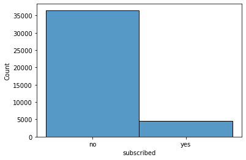

```python
# Plotting the 'subscribed' frequency
sns.histplot(df, x='subscribed')
```

```python
 #Crosstab between types of jobs and number of subscribers
print(pd.crosstab(df["job"], df['subscribed']))
```

```
subscribed       no   yes
job
admin.         9070  1352
blue-collar    8616   638
entrepreneur   1332   124
housemaid       954   106
management     2596   328
retired        1286   434
self-employed  1272   149
services       3646   323
student         597   273
technician     6013   730
unemployed      870   144
unknown         293    37
```

```python
# Crosstab between marital status and number of subscribers
pd.crosstab(df['marital_status'], df['subscribed'])
```

| subscribed marital_status | no | yes |
| --- | --- | --- |
| divorced | 4136 | 476 |
| married | 22396 | 2532 |
| single | 9945 | 1618 |
| unknown | 68 | 12 |

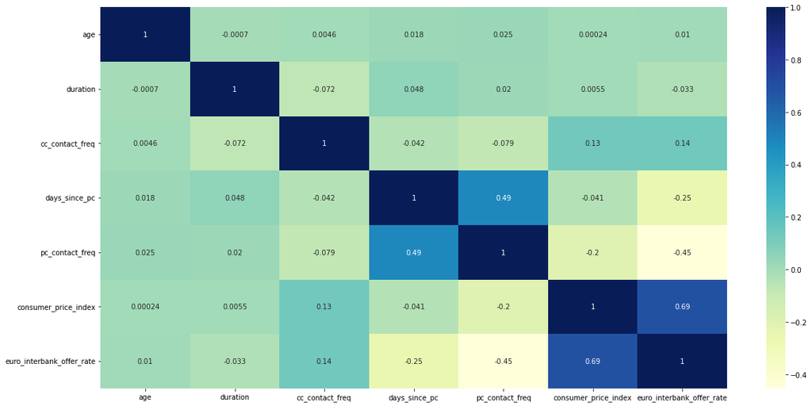

```python
# HeatMap
plt.figure(figsize=(20,10))
sns.heatmap(df.corr(), annot=True, cmap='YlGnBu')
```

```python
# make a copy dataframe with new column to binarize the subcription column
df2=df.copy()
df3=df.copy()
df3['subscribed(bin)']= df3['subscribed'].apply(lambda x: 0 if x=='no' else 1)
```

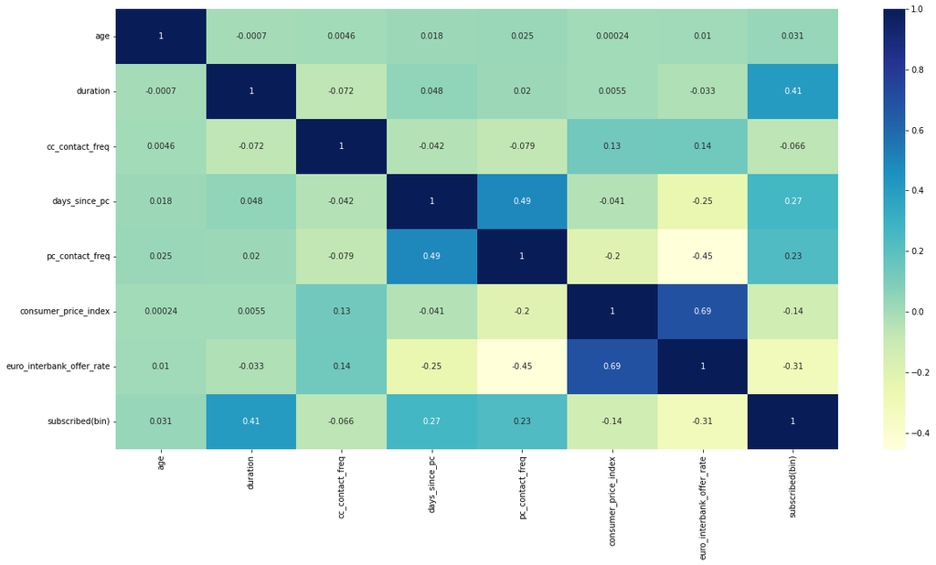

```python
# check correlation of features with the response column
plt.figure(figsize=(20,10))
sns.heatmap(df3.corr(), annot=True, cmap='YlGnBu')
```

```python
# check for job, age and education response to subscription
job_response = pd.crosstab(df['subscribed'], df['job']).apply(lambda x: (x/x.sum())*100).transpose()
Age_response = pd.crosstab(df['subscribed'], df['age']).apply(lambda x: (x/x.sum())*100).transpose()
Education_response = pd.crosstab(df['subscribed'], df['education']).apply(lambda x: (x/x.sum())*100).transpose()
```

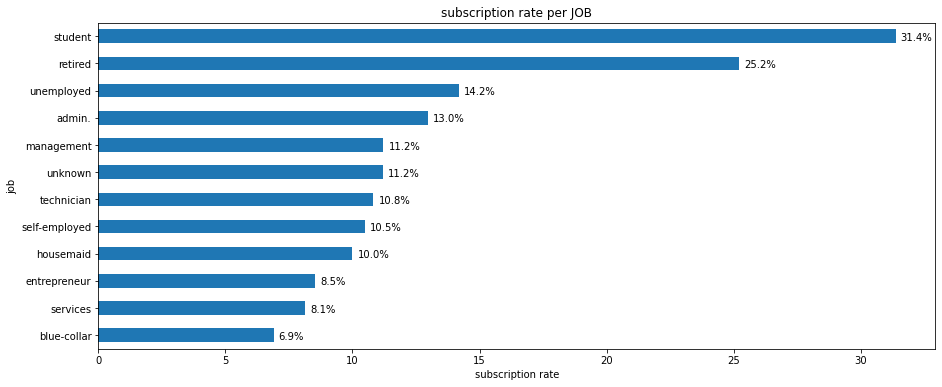

```python
# plot for job categories
barh_plot = job_response['yes'].sort_values().plot(kind='barh', figsize=(15,6))
for patch, label in zip(barh_plot.patches, job_response['yes'].sort_values().round(1).astype(str)):
    barh_plot.text(patch.get_width()+.2, patch.get_y()+.1, label+'%')
plt.xlabel('subscription rate')
plt.title('subscription rate per JOB')
```

Students and Retired People yet have the most subscriptions rates

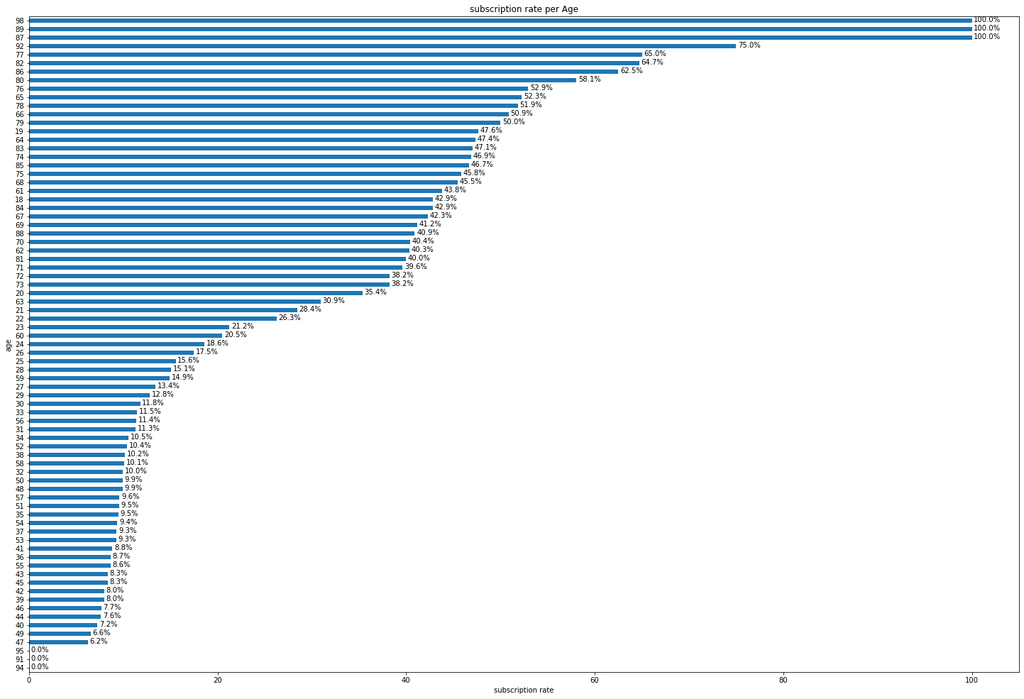

```python
#plot for age categories
barh_plot = Age_response['yes'].sort_values().plot(kind='barh', figsize=(25,17))
for patch, label in zip(barh_plot.patches, Age_response['yes'].sort_values().round(1).astype(str)):
    barh_plot.text(patch.get_width()+.2, patch.get_y()+.1, label+'%')
plt.xlabel('subscription rate')
plt.title('subscription rate per Age')
```

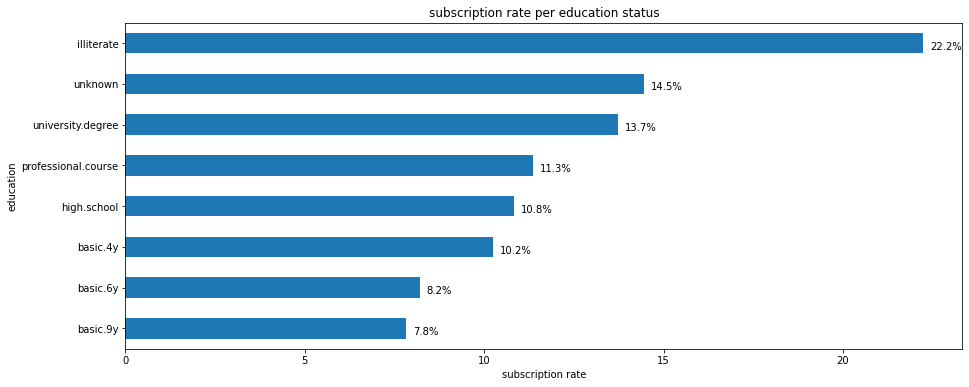

```python
#plot for education categories

barh_plot = Education_response['yes'].sort_values().plot(kind='barh', figsize=(15,6))
for patch, label in zip(barh_plot.patches, Education_response['yes'].sort_values().round(1).astype(str)):
    barh_plot.text(patch.get_width()+.2, patch.get_y()+.1, label+'%')
plt.xlabel('subscription rate')
plt.title('subscription rate per education status')
```

```python
#defaut features does not play important role and so it is dropped
df2.groupby(['subscribed','defaulter']).size()
```

```
subscribed  defaulter
no          no           28388
            unknown       8154
            yes              3
yes         no            4195
            unknown        443
dtype: int64
```

```python
df2.drop(['defaulter'],axis=1, inplace=True)
```

```python
# 'customer_id', 'first_name', 'last_name',  and 'email_id are all important features but are not needed for the modelling and so dropped
df2.drop(['customer_id', 'first_name', 'last_name', 'email_id'], axis=1, inplace=True)
```

```python
# selected columns for modelling
df2.columns
```

```
Index(['age', 'job', 'marital_status', 'education', 'home_loan',
       'personal_loan', 'communication_type', 'last_contacted', 'day_of_week',
       'duration', 'cc_contact_freq', 'days_since_pc', 'pc_contact_freq',
       'pc_outcome', 'consumer_price_index', 'euro_interbank_offer_rate',
       'subscribed'],
      dtype='object')
```

```python
dfs=df2.copy()
df3.drop(['customer_id', 'first_name', 'last_name', 'email_id', 'defaulter','subscribed'], axis=1, inplace=True)
df3
```

|  | age | job | marital_status | education | home_loan | personal_loan | communication_type | last_contacted | day_of_week | duration | cc_contact_freq | days_since_pc | pc_contact_freq | pc_outcome | consumer_price_index | euro_interbank_offer_rate | subscribed(bin) |
| --- | --- | --- | --- | --- | --- | --- | --- | --- | --- | --- | --- | --- | --- | --- | --- | --- | --- |
| 0 | 56 | housemaid | married | basic.4y | no | no | telephone | may | mon | 261 | 1 | 0 | 0 | nonexistent | 93.994 | 4.857 | 0 |
| 1 | 57 | services | married | high.school | no | no | telephone | may | mon | 149 | 1 | 0 | 0 | nonexistent | 93.994 | 4.857 | 0 |
| 2 | 37 | services | married | high.school | yes | no | telephone | may | mon | 226 | 1 | 0 | 0 | nonexistent | 93.994 | 4.857 | 0 |
| 3 | 40 | admin. | married | basic.6y | no | no | telephone | may | mon | 151 | 1 | 0 | 0 | nonexistent | 93.994 | 4.857 | 0 |
| 4 | 56 | services | married | high.school | no | yes | telephone | may | mon | 307 | 1 | 0 | 0 | nonexistent | 93.994 | 4.857 | 0 |
| ... | ... | ... | ... | ... | ... | ... | ... | ... | ... | ... | ... | ... | ... | ... | ... | ... | ... |
| 41178 | 73 | retired | married | professional.course | yes | no | cellular | nov | fri | 334 | 1 | 0 | 0 | nonexistent | 94.767 | 1.028 | 1 |
| 41179 | 46 | blue-collar | married | professional.course | no | no | cellular | nov | fri | 383 | 1 | 0 | 0 | nonexistent | 94.767 | 1.028 | 0 |
| 41180 | 56 | retired | married | university.degree | yes | no | cellular | nov | fri | 189 | 2 | 0 | 0 | nonexistent | 94.767 | 1.028 | 0 |
| 41181 | 44 | technician | married | professional.course | no | no | cellular | nov | fri | 442 | 1 | 0 | 0 | nonexistent | 94.767 | 1.028 | 1 |
| 41182 | 74 | retired | married | professional.course | yes | no | cellular | nov | fri | 239 | 3 | 0 | 1 | failure | 94.767 | 1.028 | 0 |

41183 rows × 17 columns

```python
x3=df3.iloc[:,:16]
y3=df3.iloc[:,16]
```

```python
x3d=pd.get_dummies(x3)
```

```python
#x3s=sc.fit_transform(x3)
```

```python
#label encoding for all categorical variables in dataset
label_encoder = LabelEncoder()
df2['job'] = label_encoder.fit_transform(df2['job'])
df2['marital_status'] = label_encoder.fit_transform(df2['marital_status'])
df2['education'] = label_encoder.fit_transform(df2['education'])
df2['home_loan'] = label_encoder.fit_transform(df2['home_loan'])
df2['personal_loan'] = label_encoder.fit_transform(df2['personal_loan'])
df2['communication_type'] = label_encoder.fit_transform(df2['communication_type'])
df2['last_contacted'] = label_encoder.fit_transform(df2['last_contacted'])
df2['day_of_week'] = label_encoder.fit_transform(df2['day_of_week'])
df2['duration'] = label_encoder.fit_transform(df2['duration'])
df2['cc_contact_freq'] = label_encoder.fit_transform(df2['cc_contact_freq'])
df2['days_since_pc'] = label_encoder.fit_transform(df2['days_since_pc'])
df2['pc_contact_freq'] = label_encoder.fit_transform(df2['pc_contact_freq'])
df2['pc_outcome'] = label_encoder.fit_transform(df2['pc_outcome'])
df2['consumer_price_index'] = label_encoder.fit_transform(df2['consumer_price_index'])
df2['euro_interbank_offer_rate'] = label_encoder.fit_transform(df2['euro_interbank_offer_rate'])
```

```python
dfs
```

|  | age | job | marital_status | education | home_loan | personal_loan | communication_type | last_contacted | day_of_week | duration | cc_contact_freq | days_since_pc | pc_contact_freq | pc_outcome | consumer_price_index | euro_interbank_offer_rate | subscribed |
| --- | --- | --- | --- | --- | --- | --- | --- | --- | --- | --- | --- | --- | --- | --- | --- | --- | --- |
| 0 | 56 | housemaid | married | basic.4y | no | no | telephone | may | mon | 261 | 1 | 0 | 0 | nonexistent | 93.994 | 4.857 | no |
| 1 | 57 | services | married | high.school | no | no | telephone | may | mon | 149 | 1 | 0 | 0 | nonexistent | 93.994 | 4.857 | no |
| 2 | 37 | services | married | high.school | yes | no | telephone | may | mon | 226 | 1 | 0 | 0 | nonexistent | 93.994 | 4.857 | no |
| 3 | 40 | admin. | married | basic.6y | no | no | telephone | may | mon | 151 | 1 | 0 | 0 | nonexistent | 93.994 | 4.857 | no |
| 4 | 56 | services | married | high.school | no | yes | telephone | may | mon | 307 | 1 | 0 | 0 | nonexistent | 93.994 | 4.857 | no |
| ... | ... | ... | ... | ... | ... | ... | ... | ... | ... | ... | ... | ... | ... | ... | ... | ... | ... |
| 41178 | 73 | retired | married | professional.course | yes | no | cellular | nov | fri | 334 | 1 | 0 | 0 | nonexistent | 94.767 | 1.028 | yes |
| 41179 | 46 | blue-collar | married | professional.course | no | no | cellular | nov | fri | 383 | 1 | 0 | 0 | nonexistent | 94.767 | 1.028 | no |
| 41180 | 56 | retired | married | university.degree | yes | no | cellular | nov | fri | 189 | 2 | 0 | 0 | nonexistent | 94.767 | 1.028 | no |
| 41181 | 44 | technician | married | professional.course | no | no | cellular | nov | fri | 442 | 1 | 0 | 0 | nonexistent | 94.767 | 1.028 | yes |
| 41182 | 74 | retired | married | professional.course | yes | no | cellular | nov | fri | 239 | 3 | 0 | 1 | failure | 94.767 | 1.028 | no |

41183 rows × 17 columns

```python
# dividing columns into features and response
X = df2.iloc[:,0:16] # all independent variables needed for modelling
y = df3.iloc[:,16]
```

```python
# use SMOTE techniques to balance the data
smt = SMOTE(random_state=25)

X_SM, y_SM = smt.fit_resample(X, y)

pd.Series(y_SM).value_counts()
```

```
0    36545
1    36545
Name: subscribed(bin), dtype: int64
```

```python
# spliting data into train and test for both dependent and independent variables with 80:20 ratio
X_train, X_test, y_train, y_test = train_test_split(X_SM, y_SM, test_size=0.2, random_state=0)
X_train, X_test, y_train, y_test = train_test_split(X, y, test_size=0.2, random_state=0)
```

## Building a Logistic Regression model

```python
# fit the train data using the Logit method of statsmodel for logistic regression
log_reg1 = sm.Logit(y_train,sm.add_constant(X_train)).fit()
```

```
Optimization terminated successfully.
         Current function value: 0.216867
         Iterations 8
```

```python
# make prediction and check model perfromance
X_testc = tools.add_constant(X_test)
prediction_1 = list(map(round, log_reg1.predict(X_testc)))
print(accuracy_score(y_test, prediction_1))
print("Precision: ",round(precision_score(y_test,prediction_1),2),"Recall: ",round(recall_score(y_test,prediction_1),2))
print('Classification report:\n', classification_report(y_test, prediction_1))
```

```
0.9141677795313828
Precision:  0.68 Recall:  0.44
Classification report:
               precision    recall  f1-score   support

           0       0.93      0.97      0.95      7309
           1       0.68      0.44      0.54       928

    accuracy                           0.91      8237
   macro avg       0.81      0.71      0.75      8237
weighted avg       0.90      0.91      0.91      8237
```

## Checking Multicollinearity

- In order to make statistical inferences from a logistic regression model, it is important to ensure that there is no multicollinearity present in the data.

```python
# check multicolinearity
vif_scores = pd.DataFrame()
vif_scores["Attribute"] = X.columns

# calculating VIF for each feature
vif_scores["VIF Scores"] = [variance_inflation_factor(X_train, i) for i in range(len(X.columns))]

display(vif_scores)
```

|  | Attribute | VIF Scores |
| --- | --- | --- |
| 0 | age | 12.202142 |
| 1 | job | 2.094581 |
| 2 | marital_status | 4.598576 |
| 3 | education | 4.071374 |
| 4 | home_loan | 2.167725 |
| 5 | personal_loan | 1.204798 |
| 6 | communication_type | 2.786751 |
| 7 | last_contacted | 4.538431 |
| 8 | day_of_week | 3.018483 |
| 9 | duration | 2.139930 |
| 10 | cc_contact_freq | 1.368403 |
| 11 | days_since_pc | 2.002343 |
| 12 | pc_contact_freq | 2.224045 |
| 13 | pc_outcome | 11.623172 |
| 14 | consumer_price_index | 16.569377 |
| 15 | euro_interbank_offer_rate | 22.049334 |

there are multiple features exceeding VIF 10.0, the highest which is euro_interbank_offer_rate will be removed first

```python
xsB=X_train.drop(['euro_interbank_offer_rate'], axis=1)
vif_scores = pd.DataFrame()
vif_scores["Attribute"] = xsB.columns

# calculating VIF for each feature
vif_scores["VIF Scores"] = [variance_inflation_factor(xsB.values, i) for i in range(len(xsB.columns))]

display(vif_scores)
```

|  | Attribute | VIF Scores |
| --- | --- | --- |
| 0 | age | 10.766586 |
| 1 | job | 2.091343 |
| 2 | marital_status | 4.426397 |
| 3 | education | 4.005729 |
| 4 | home_loan | 2.155180 |
| 5 | personal_loan | 1.203522 |
| 6 | communication_type | 2.712530 |
| 7 | last_contacted | 4.537146 |
| 8 | day_of_week | 2.970522 |
| 9 | duration | 2.138469 |
| 10 | cc_contact_freq | 1.360448 |
| 11 | days_since_pc | 1.908755 |
| 12 | pc_contact_freq | 2.141933 |
| 13 | pc_outcome | 11.486226 |
| 14 | consumer_price_index | 10.675785 |

second feature to be dropped is pc_outcome with VIF score of 11.5

```python
xsB=xsB.drop(['pc_outcome'], axis=1)
vif_scores = pd.DataFrame()
vif_scores["Attribute"] = xsB.columns

# calculating VIF for each feature
vif_scores["VIF Scores"] = [variance_inflation_factor(xsB.values, i) for i in range(len(xsB.columns))]

display(vif_scores)
```

|  | Attribute | VIF Scores |
| --- | --- | --- |
| 0 | age | 9.147495 |
| 1 | job | 2.087795 |
| 2 | marital_status | 4.203175 |
| 3 | education | 3.917850 |
| 4 | home_loan | 2.145230 |
| 5 | personal_loan | 1.203220 |
| 6 | communication_type | 2.700458 |
| 7 | last_contacted | 4.493394 |
| 8 | day_of_week | 2.947044 |
| 9 | duration | 2.127525 |
| 10 | cc_contact_freq | 1.359719 |
| 11 | days_since_pc | 1.348248 |
| 12 | pc_contact_freq | 1.571324 |
| 13 | consumer_price_index | 9.793274 |

after the removeing the pc_outcome, the factors seem to stabilize with no feature exceeding 10.0 VIF. Thus multicolinearity has been checked and modelling is done once again

```python
# Check insignificant variables that is having (P-value > 0.05)
log_reg2 = sm.Logit(y_train,sm.add_constant(xsB)).fit()
log_reg2.summary()
```

```
Optimization terminated successfully.
         Current function value: 0.247740
         Iterations 8
```

Logit Regression Results

| Dep. Variable: | subscribed(bin) | No. Observations: | 32946 |
| --- | --- | --- | --- |
| Model: | Logit | Df Residuals: | 32931 |
| Method: | MLE | Df Model: | 14 |
| Date: | Tue, 27 Dec 2022 | Pseudo R-squ.: | 0.2961 |
| Time: | 06:48:52 | Log-Likelihood: | -8162.0 |
| converged: | True | LL-Null: | -11595. |
| Covariance Type: | nonrobust | LLR p-value: | 0.000 |

|  | coef | std err | z | P>\|z\| | [0.025 | 0.975] |
| --- | --- | --- | --- | --- | --- | --- |
| const | -4.2174 | 0.150 | -28.023 | 0.000 | -4.512 | -3.922 |
| age | 0.0175 | 0.002 | 8.620 | 0.000 | 0.014 | 0.021 |
| job | 0.0099 | 0.006 | 1.708 | 0.088 | -0.001 | 0.021 |
| marital_status | 0.2888 | 0.038 | 7.662 | 0.000 | 0.215 | 0.363 |
| education | 0.0920 | 0.010 | 9.069 | 0.000 | 0.072 | 0.112 |
| home_loan | 0.0090 | 0.021 | 0.426 | 0.670 | -0.033 | 0.051 |
| personal_loan | -0.0331 | 0.029 | -1.130 | 0.259 | -0.091 | 0.024 |
| communication_type | -0.6009 | 0.062 | -9.761 | 0.000 | -0.722 | -0.480 |
| last_contacted | -0.0121 | 0.008 | -1.422 | 0.155 | -0.029 | 0.005 |
| day_of_week | 0.0356 | 0.015 | 2.378 | 0.017 | 0.006 | 0.065 |
| duration | 0.0044 | 7.46e-05 | 59.292 | 0.000 | 0.004 | 0.005 |
| cc_contact_freq | -0.0817 | 0.012 | -6.564 | 0.000 | -0.106 | -0.057 |
| days_since_pc | 0.2479 | 0.013 | 19.510 | 0.000 | 0.223 | 0.273 |
| pc_contact_freq | 0.5296 | 0.036 | 14.856 | 0.000 | 0.460 | 0.599 |
| consumer_price_index | -0.0635 | 0.004 | -15.218 | 0.000 | -0.072 | -0.055 |

from summary table above, four features which are 'job', 'home_loan','personal_loan' and'last_contacted' have pvalue greater than 0.05 and thus removed.

```python
# four columns has pvalue greater than 0.05 to be dropped

Xn=xsB.drop(['job', 'home_loan','personal_loan','last_contacted'], axis=1)

log_reg3 = sm.Logit(y_train,sm.add_constant(Xn)).fit() # fit model on new features dataframe
X_testn=X_test.drop(['job', 'home_loan','personal_loan','last_contacted','euro_interbank_offer_rate', 'pc_outcome'], axis=1)
X_testnn = tools.add_constant(X_testn)

prediction3 = list(map(round, log_reg3.predict(X_testnn)))
```

```
Optimization terminated successfully.
         Current function value: 0.247838
         Iterations 8
```

## Coefficient interpretations

```python
# check coefficients of all important features
log_reg3.params
```

```
const                  -4.250698
age                     0.017669
marital_status          0.291036
education               0.094510
communication_type     -0.624146
day_of_week             0.034578
duration                0.004419
cc_contact_freq        -0.081205
days_since_pc           0.247892
pc_contact_freq         0.522742
consumer_price_index   -0.062661
dtype: float64
```

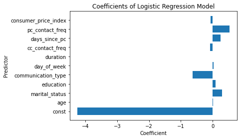

```python
# plot for coefficients interpretation
predictors = log_reg3.params.index
coefficients = log_reg3.params.values

plt.barh(predictors, coefficients)
plt.xlabel('Coefficient')
plt.ylabel('Predictor')
plt.title('Coefficients of Logistic Regression Model')
```

from the output above there are negative coefficients of varying magnitude such as 'communication_type', 'contact frequency for current campaign' and 'consumer price index'. an increase in this factors is associated with a decrease probability of their corresponding subscription status. while for the others which are positive, increase in the factors is associated with increase probability of their corresponding subscription status.

## Model performance evaluation

```python
# print('Classification report:\n', classification_report(y_test, y_pred_new_threshold))
print('Classification report:\n', classification_report(y_test, prediction3))
```

```
Classification report:
               precision    recall  f1-score   support

           0       0.92      0.98      0.95      7309
           1       0.64      0.32      0.42       928

    accuracy                           0.90      8237
   macro avg       0.78      0.65      0.69      8237
weighted avg       0.89      0.90      0.89      8237
```

```python
prediction4 = list(log_reg3.predict(X_testnn))


# Set the threshold value
threshold = 0.32

# Predict the class labels
predictions = [1 if prob > threshold else 0 for prob in prediction4]

# Calculate the evaluation metric
print('Classification report:\n', classification_report(y_test, predictions))
```

```
Classification report:
               precision    recall  f1-score   support

           0       0.94      0.95      0.94      7309
           1       0.57      0.48      0.52       928

    accuracy                           0.90      8237
   macro avg       0.75      0.72      0.73      8237
weighted avg       0.89      0.90      0.90      8237
```

After setting the threshold value to 0.32 rather than 0.5, the F1-score average value increase from 89% to 90%

```python
confusion_matrix(y_test, predictions)
```

```
array([[6971,  338],
       [ 480,  448]], dtype=int64)
```

Therefore, the model predicts 7419 (6971+448) data correctly and 818 (338+480) data incorrectly.

## Final Model Summary

```python
# check final summary
log_reg3.summary()
```

Logit Regression Results

| Dep. Variable: | subscribed(bin) | No. Observations: | 32946 |
| --- | --- | --- | --- |
| Model: | Logit | Df Residuals: | 32935 |
| Method: | MLE | Df Model: | 10 |
| Date: | Tue, 27 Dec 2022 | Pseudo R-squ.: | 0.2958 |
| Time: | 06:48:54 | Log-Likelihood: | -8165.3 |
| converged: | True | LL-Null: | -11595. |
| Covariance Type: | nonrobust | LLR p-value: | 0.000 |

|  | coef | std err | z | P>\|z\| | [0.025 | 0.975] |
| --- | --- | --- | --- | --- | --- | --- |
| const | -4.2507 | 0.141 | -30.185 | 0.000 | -4.527 | -3.975 |
| age | 0.0177 | 0.002 | 8.716 | 0.000 | 0.014 | 0.022 |
| marital_status | 0.2910 | 0.038 | 7.726 | 0.000 | 0.217 | 0.365 |
| education | 0.0945 | 0.010 | 9.387 | 0.000 | 0.075 | 0.114 |
| communication_type | -0.6241 | 0.060 | -10.467 | 0.000 | -0.741 | -0.507 |
| day_of_week | 0.0346 | 0.015 | 2.313 | 0.021 | 0.005 | 0.064 |
| duration | 0.0044 | 7.45e-05 | 59.276 | 0.000 | 0.004 | 0.005 |
| cc_contact_freq | -0.0812 | 0.012 | -6.534 | 0.000 | -0.106 | -0.057 |
| days_since_pc | 0.2479 | 0.013 | 19.516 | 0.000 | 0.223 | 0.273 |
| pc_contact_freq | 0.5227 | 0.035 | 14.818 | 0.000 | 0.454 | 0.592 |
| consumer_price_index | -0.0627 | 0.004 | -15.160 | 0.000 | -0.071 | -0.055 |

```python
log_reg3.summary2()
```

| Model: | Logit | Pseudo R-squared: | 0.296 |
| --- | --- | --- | --- |
| Dependent Variable: | subscribed(bin) | AIC: | 16352.5155 |
| Date: | 2022-12-27 06:48 | BIC: | 16444.9444 |
| No. Observations: | 32946 | Log-Likelihood: | -8165.3 |
| Df Model: | 10 | LL-Null: | -11595. |
| Df Residuals: | 32935 | LLR p-value: | 0.0000 |
| Converged: | 1.0000 | Scale: | 1.0000 |
| No. Iterations: | 8.0000 |  |  |

|  | Coef. | Std.Err. | z | P>\|z\| | [0.025 | 0.975] |
| --- | --- | --- | --- | --- | --- | --- |
| const | -4.2507 | 0.1408 | -30.1855 | 0.0000 | -4.5267 | -3.9747 |
| age | 0.0177 | 0.0020 | 8.7159 | 0.0000 | 0.0137 | 0.0216 |
| marital_status | 0.2910 | 0.0377 | 7.7256 | 0.0000 | 0.2172 | 0.3649 |
| education | 0.0945 | 0.0101 | 9.3866 | 0.0000 | 0.0748 | 0.1142 |
| communication_type | -0.6241 | 0.0596 | -10.4674 | 0.0000 | -0.7410 | -0.5073 |
| day_of_week | 0.0346 | 0.0150 | 2.3128 | 0.0207 | 0.0053 | 0.0639 |
| duration | 0.0044 | 0.0001 | 59.2762 | 0.0000 | 0.0043 | 0.0046 |
| cc_contact_freq | -0.0812 | 0.0124 | -6.5336 | 0.0000 | -0.1056 | -0.0568 |
| days_since_pc | 0.2479 | 0.0127 | 19.5157 | 0.0000 | 0.2230 | 0.2728 |
| pc_contact_freq | 0.5227 | 0.0353 | 14.8180 | 0.0000 | 0.4536 | 0.5919 |
| consumer_price_index | -0.0627 | 0.0041 | -15.1600 | 0.0000 | -0.0708 | -0.0546 |

## Building a Decision Tree model

```python
# build decision tree model
X_train, X_test, y_train, y_testt = train_test_split(X, y, test_size=0.3)
tree = DecisionTreeClassifier()
Tree = tree.fit(X_train,y_train)
y_pred = Tree.predict(X_test)
```

```python
# Calculating the accuracy and check overall performance of the model
print("Precision: ",round(precision_score(y_testt,y_pred),2),"Recall: ",round(recall_score(y_testt,y_pred),2))
print("Accuracy For Decision Tree Model is:",round(accuracy_score(y_testt, y_pred)*100,2), "%")

print('Classification report:\n', classification_report(y_testt, y_pred))
```

```
Precision:  0.51 Recall:  0.52
Accuracy For Decision Tree Model is: 89.15 %
Classification report:
               precision    recall  f1-score   support

           0       0.94      0.94      0.94     10976
           1       0.51      0.52      0.52      1379

    accuracy                           0.89     12355
   macro avg       0.73      0.73      0.73     12355
weighted avg       0.89      0.89      0.89     12355
```

Here, the resultant tree is unpruned. This unpruned tree is unexplainable and not easy to understand. In the next section, let's optimize it by pruning. The maximum depth of the tree can be used as a control variable for pruning.

## Do we need to prune the tree?

```python
# prune model by setting max_depth to 3 as a pruning factor
X_train, X_test, y_train, y_testt = train_test_split(X, y, test_size=0.3)

tree = DecisionTreeClassifier(criterion='entropy',max_depth=3, random_state=0)

Tree2 = tree.fit(X_train,y_train)
y_predT = Tree2.predict(X_test)
```

```python
# Calculating the accuracy and overall performance after pruning
print("Precision: ",round(precision_score(y_testt,y_predT),2),"Recall: ",round(recall_score(y_testt,y_predT),2))
print("Accuracy For Decision Tree Model is:",round(accuracy_score(y_testt, y_predT)*100,2), "%")
print('Classification report:\n', classification_report(y_testt, y_predT))
```

```
Precision:  0.6 Recall:  0.57
Accuracy For Decision Tree Model is: 90.94 %
Classification report:
               precision    recall  f1-score   support

           0       0.95      0.95      0.95     10964
           1       0.60      0.57      0.59      1391

    accuracy                           0.91     12355
   macro avg       0.77      0.76      0.77     12355
weighted avg       0.91      0.91      0.91     12355
```

```
[Text(0.5, 0.875, 'euro_interbank_offer_rate <= 196.5\nentropy = 0.508\nsamples = 28828\nvalue = [25581, 3247]\nclass = No'),
```

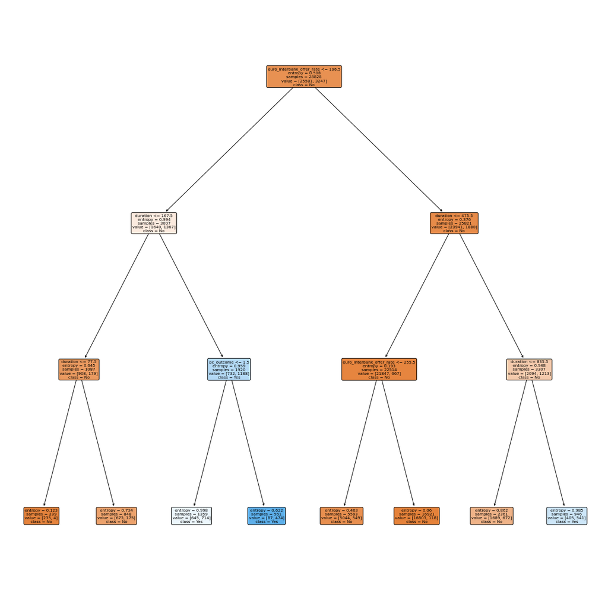

```python
# check for decision rules
plt.figure(figsize=(20, 20))
plot_tree(Tree2, filled=True, rounded=True, class_names=["No", "Yes"], feature_names=X.columns)
```

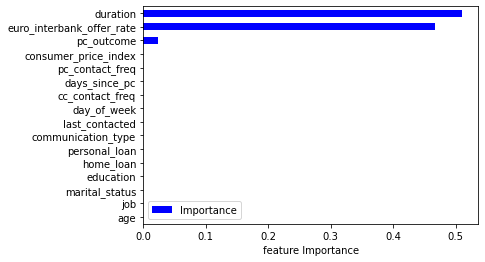

```python
Importance = pd.DataFrame({'Importance':Tree2.feature_importances_}, index=X.columns)
Importance.sort_values('Importance', axis=0, ascending=True).plot(kind='barh', color='b', )
plt.xlabel('feature Importance')
```

A Decision Tree model was successfully built for the classifcation problem. The bank will be able to predict a client's response to its telemarketing campaign before contacting him/her. The bank should priotize clients who are highly likely to accept term deposits, and call less to those who are unlikely to make term deposits.

## Model Performance Comparison and Conclusions

```python
#Calculate the performance metrics
accuracy = accuracy_score(y_test, predictions)
precision = precision_score(y_test, predictions)
recall = recall_score(y_test, predictions)
f1 = f1_score(y_test, predictions)
data = {
    "Metric": ["Accuracy", "Precision", "Recall", "F1-Score"],
    "Logistic Regression": [accuracy, precision, recall, f1],
    "Decision Tree": [accuracy_score(y_testt, y_predT), precision_score(y_testt, y_predT), recall_score(y_testt, y_predT), f1_score(y_testt, y_predT)],
}
modp = pd.DataFrame(data)
modp
```

|  | Metric | Logistic Regression | Decision Tree |
| --- | --- | --- | --- |
| 0 | Accuracy | 0.900692 | 0.909429 |
| 1 | Precision | 0.569975 | 0.603501 |
| 2 | Recall | 0.482759 | 0.570093 |
| 3 | F1-Score | 0.522754 | 0.586322 |

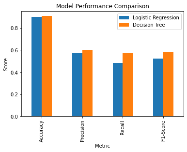

```python
# Create the plot
fig, ax = plt.subplots()
modp.plot.bar(x="Metric", y=["Logistic Regression", "Decision Tree"], ax=ax)

# Add labels and title
ax.set_xlabel("Metric")
ax.set_ylabel("Score")
ax.set_title("Model Performance Comparison")
```

#### key take-away for business

From the performance summary table above, it can be derived that Decision Tree Model performed the best in all metrics considered. This indicates that previous campaign outcome, duration of contacts and euro interbank exhange rate and all associated factors has to be seriously considered and analysed in enhancing the subscription rate of the customers

## K-means Clustering

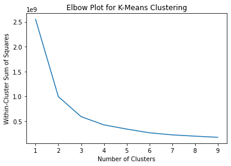

```python
k_values = range(1, 10)

# Create an empty list to store the within-cluster sum of squares for each value of k
wcss = []

# Iterate over the values of k
for k in k_values:
    # Create the k-means model
    kmeans_model = KMeans(n_clusters=k)

    # Fit the model to the data
    kmeans_model.fit(X)

    # Calculate the within-cluster sum of squares for the model
    wcss.append(kmeans_model.inertia_)

# Create the plot
plt.plot(k_values, wcss)

# Add labels and title
plt.xlabel("Number of Clusters")
plt.ylabel("Within-Cluster Sum of Squares")
plt.title("Elbow Plot for K-Means Clustering")
```

```python
kmeans_model = KMeans(n_clusters=3)

# Fit the model to the data
kmeans_model.fit(X)

# Predict the clusters for each data point
clusters3 = kmeans_model.predict(X)
```

```python
silhouette_score(X, clusters3)
```

```
0.5314827388782579
```

```python
kmeans_model = KMeans(n_clusters=4)

# Fit the model to the data
kmeans_model.fit(X)

# Predict the clusters for each data point
clusters4 = kmeans_model.predict(X)
```

```python
silhouette_score(X, clusters4)
```

```
0.45312718242617206
```

```python
df['clusters']=clusters4
```

```python
df.head()
```

|  | customer_id | email_id | first_name | last_name | age | job | marital_status | education | defaulter | home_loan | personal_loan | communication_type | last_contacted | day_of_week | duration | cc_contact_freq | days_since_pc | pc_contact_freq | pc_outcome | consumer_price_index | euro_interbank_offer_rate | subscribed | clusters |
| --- | --- | --- | --- | --- | --- | --- | --- | --- | --- | --- | --- | --- | --- | --- | --- | --- | --- | --- | --- | --- | --- | --- | --- |
| 0 | 61e41ab36fb571a283ba252b | jared84@example.org | Aaron | Austin | 56 | housemaid | married | basic.4y | no | no | no | telephone | may | mon | 261 | 1 | 0 | 0 | nonexistent | 93.994 | 4.857 | no | 2 |
| 1 | 61e41ab36fb571a283ba252c | gsanchez@example.net | Aaron | Gray | 57 | services | married | high.school | unknown | no | no | telephone | may | mon | 149 | 1 | 0 | 0 | nonexistent | 93.994 | 4.857 | no | 0 |
| 2 | 61e41ab36fb571a283ba252d | donald41@example.net | Aaron | Walker | 37 | services | married | high.school | no | yes | no | telephone | may | mon | 226 | 1 | 0 | 0 | nonexistent | 93.994 | 4.857 | no | 2 |
| 3 | 61e41ab36fb571a283ba252e | ariel87@example.com | Aaron | Shelton | 40 | admin. | married | basic.6y | no | no | no | telephone | may | mon | 151 | 1 | 0 | 0 | nonexistent | 93.994 | 4.857 | no | 0 |
| 4 | 61e41ab36fb571a283ba252f | thomasjeff@example.com | Aaron | Johnson | 56 | services | married | high.school | no | no | yes | telephone | may | mon | 307 | 1 | 0 | 0 | nonexistent | 93.994 | 4.857 | no | 2 |

```python
statistics = df.groupby('clusters').describe()
```

```python
statistics
```

| clusters | age count | age mean | age std | age min | age 25% | age 50% | age 75% | age max | duration count | duration mean | duration std | duration min | duration 25% | duration 50% | duration 75% | duration max | cc_contact_freq count | cc_contact_freq mean | cc_contact_freq std | cc_contact_freq min | cc_contact_freq 25% | cc_contact_freq 50% | cc_contact_freq 75% | cc_contact_freq max | days_since_pc count | days_since_pc mean | days_since_pc std | days_since_pc min | days_since_pc 25% | … |
| --- | --- | --- | --- | --- | --- | --- | --- | --- | --- | --- | --- | --- | --- | --- | --- | --- | --- | --- | --- | --- | --- | --- | --- | --- | --- | --- | --- | --- | --- | --- |
| 0 | 23227.0 | 39.996082 | 10.171615 | 18.0 | 32.0 | 38.0 | 47.0 | 95.0 | 23227.0 | 111.320618 | 51.991694 | 0.0 | 72.0 | 111.0 | 154.0 | 211.0 | 23227.0 | 2.781117 | 3.179462 | 1.0 | 1.0 | 2.0 | 3.0 | 43.0 | 23227.0 | 0.122487 | 0.999150 | 0.0 | 0.0 | … |
| 1 | 4441.0 | 40.276289 | 10.784791 | 18.0 | 32.0 | 38.0 | 48.0 | 98.0 | 4441.0 | 607.209863 | 112.817169 | 452.0 | 510.0 | 586.0 | 691.0 | 867.0 | 4441.0 | 2.341139 | 2.161298 | 1.0 | 1.0 | 2.0 | 3.0 | 29.0 | 4441.0 | 0.348120 | 1.750406 | 0.0 | 0.0 | … |
| 2 | 12088.0 | 40.039957 | 10.784423 | 18.0 | 32.0 | 38.0 | 47.0 | 98.0 | 12088.0 | 299.683074 | 68.242768 | 181.0 | 241.0 | 288.0 | 351.0 | 459.0 | 12088.0 | 2.244705 | 2.049002 | 1.0 | 1.0 | 2.0 | 3.0 | 56.0 | 12088.0 | 0.358206 | 1.684785 | 0.0 | 0.0 | … |
| 3 | 1427.0 | 39.640505 | 10.071782 | 19.0 | 32.0 | 38.0 | 46.0 | 92.0 | 1427.0 | 1213.252278 | 400.098895 | 865.0 | 961.5 | 1096.0 | 1322.0 | 4918.0 | 1427.0 | 2.533287 | 2.246576 | 1.0 | 1.0 | 2.0 | 3.0 | 26.0 | 1427.0 | 0.266994 | 1.516454 | 0.0 | 0.0 | … |

## Cluster profiles

```python
# Check the names of the customers in each cluster who didn't subscribed.

# for first cluster
nw=df[(df['clusters']==0) & (df['subscribed']=='no') ]
nw[['first_name', 'last_name', 'subscribed', 'clusters']]
```

|  | first_name | last_name | subscribed | clusters |
| --- | --- | --- | --- | --- |
| 1 | Aaron | Gray | no | 0 |
| 3 | Aaron | Shelton | no | 0 |
| 5 | Aaron | Goodman | no | 0 |
| 6 | Aaron | Johnson | no | 0 |
| 9 | Aaron | Williams | no | 0 |
| ... | ... | ... | ... | ... |
| 41170 | Roger | Vaughan | no | 0 |
| 41172 | Roger | Ferguson | no | 0 |
| 41174 | Roger | Kelly | no | 0 |
| 41177 | Roger | Martinez | no | 0 |
| 41180 | Roger | Price | no | 0 |

22561 rows × 4 columns

```python
# for second cluster
nw=df[(df['clusters']==1) & (df['subscribed']=='no') ]
nw[['first_name', 'last_name', 'subscribed', 'clusters']]
```

|  | first_name | last_name | subscribed | clusters |
| --- | --- | --- | --- | --- |
| 38 | Aaron | Orozco | no | 1 |
| 46 | Aaron | Page | no | 1 |
| 57 | Aaron | Flynn | no | 1 |
| 61 | Aaron | Richardson | no | 1 |
| 86 | Aaron | Patel | no | 1 |
| ... | ... | ... | ... | ... |
| 40957 | Robert | Robertson | no | 1 |
| 41066 | Robin | Dalton | no | 1 |
| 41079 | Robin | Rodgers | no | 1 |
| 41124 | Rodney | Johnson | no | 1 |
| 41156 | Rodney | Bell | no | 1 |

2986 rows × 4 columns

```python
# for third cluster
nw=df[(df['clusters']==2) & (df['subscribed']=='no') ]
nw[['first_name', 'last_name', 'subscribed', 'clusters']]
```

|  | first_name | last_name | subscribed | clusters |
| --- | --- | --- | --- | --- |
| 0 | Aaron | Austin | no | 2 |
| 2 | Aaron | Walker | no | 2 |
| 4 | Aaron | Johnson | no | 2 |
| 7 | Aaron | Preston | no | 2 |
| 8 | Aaron | Davidson | no | 2 |
| ... | ... | ... | ... | ... |
| 41165 | Roger | Anderson | no | 2 |
| 41171 | Roger | Jenkins | no | 2 |
| 41175 | Roger | Harrison | no | 2 |
| 41179 | Roger | Wilson | no | 2 |
| 41182 | Roger | Jefferson | no | 2 |

10414 rows × 4 columns

```python
# for forth cluster
nw=df[(df['clusters']==3) & (df['subscribed']=='no') ]
nw[['first_name', 'last_name', 'subscribed', 'clusters']]
```

|  | first_name | last_name | subscribed | clusters |
| --- | --- | --- | --- | --- |
| 37 | Aaron | Bullock | no | 3 |
| 164 | Aaron | Kelly | no | 3 |
| 199 | Abigail | Cooke | no | 3 |
| 276 | Adam | Eaton | no | 3 |
| 590 | Alec | Rivera | no | 3 |
| ... | ... | ... | ... | ... |
| 40532 | Robert | Figueroa | no | 3 |
| 40831 | Robert | Stein | no | 3 |
| 40835 | Robert | Riley | no | 3 |
| 40874 | Robert | Porter | no | 3 |
| 41116 | Rodney | Phelps | no | 3 |

584 rows × 4 columns

```python
# set new column of features as labels for the clusters
X['clusters']=clusters4
```

```python
# build profile statistical summary for all features
pd.set_option('display.max_columns', None)
clust_profile=X.drop(['day_of_week','personal_loan', 'consumer_price_index'], axis=1)
clust_profile=clust_profile.groupby('clusters').describe()
clust_profile['freq']=X['clusters'].value_counts().sort_index()
clust_profile
```

| clusters | age count | age mean | age std | age min | age 25% | age 50% | age 75% | age max | job count | job mean | job std | job min | job 25% | job 50% | job 75% | job max | marital_status count | marital_status mean | marital_status std | marital_status min | marital_status 25% | marital_status 50% | marital_status 75% | marital_status max | education count | education mean | education std | education min | education 25% | … |
| --- | --- | --- | --- | --- | --- | --- | --- | --- | --- | --- | --- | --- | --- | --- | --- | --- | --- | --- | --- | --- | --- | --- | --- | --- | --- | --- | --- | --- | --- | --- |
| 0 | 23227.0 | 39.996082 | 10.171615 | 18.0 | 32.0 | 38.0 | 47.0 | 95.0 | 23227.0 | 3.743617 | 3.615629 | 0.0 | 0.0 | 2.0 | 7.0 | 11.0 | 23227.0 | 1.165540 | 0.607599 | 0.0 | 1.0 | 1.0 | 2.0 | 3.0 | 23227.0 | 3.776768 | 2.128094 | 0.0 | 2.0 | … |
| 1 | 4441.0 | 40.276289 | 10.784791 | 18.0 | 32.0 | 38.0 | 48.0 | 98.0 | 4441.0 | 3.730466 | 3.562896 | 0.0 | 1.0 | 2.0 | 7.0 | 11.0 | 4441.0 | 1.178563 | 0.616112 | 0.0 | 1.0 | 1.0 | 2.0 | 3.0 | 4441.0 | 3.656159 | 2.164515 | 0.0 | 2.0 | … |
| 2 | 12088.0 | 40.039957 | 10.784423 | 18.0 | 32.0 | 38.0 | 47.0 | 98.0 | 12088.0 | 3.702184 | 3.574889 | 0.0 | 1.0 | 2.0 | 7.0 | 11.0 | 12088.0 | 1.181502 | 0.608792 | 0.0 | 1.0 | 1.0 | 2.0 | 3.0 | 12088.0 | 3.728326 | 2.142245 | 0.0 | 2.0 | … |
| 3 | 1427.0 | 39.640505 | 10.071782 | 19.0 | 32.0 | 38.0 | 46.0 | 92.0 | 1427.0 | 3.571128 | 3.510306 | 0.0 | 0.0 | 2.0 | 7.0 | 11.0 | 1427.0 | 1.195515 | 0.606447 | 0.0 | 1.0 | 1.0 | 2.0 | 3.0 | 1427.0 | 3.707779 | 2.126627 | 0.0 | 2.0 | … |

```python
# check for important features from the decision tree model
clust_profile2=X[['duration','pc_outcome','euro_interbank_offer_rate','consumer_price_index','clusters']].groupby('clusters').describe()
clust_profile2
```

| clusters | duration count | duration mean | duration std | duration min | duration 25% | duration 50% | duration 75% | duration max | pc_outcome count | pc_outcome mean | pc_outcome std | pc_outcome min | pc_outcome 25% | pc_outcome 50% | pc_outcome 75% | pc_outcome max | euro_interbank_offer_rate count | euro_interbank_offer_rate mean | euro_interbank_offer_rate std | euro_interbank_offer_rate min | euro_interbank_offer_rate 25% | euro_interbank_offer_rate 50% | euro_interbank_offer_rate 75% | euro_interbank_offer_rate max | consumer_price_index count | consumer_price_index mean | consumer_price_index std | consumer_price_index min | consumer_price_index 25% | … |
| --- | --- | --- | --- | --- | --- | --- | --- | --- | --- | --- | --- | --- | --- | --- | --- | --- | --- | --- | --- | --- | --- | --- | --- | --- | --- | --- | --- | --- | --- | --- |
| 0 | 23227.0 | 111.320618 | 51.991694 | 0.0 | 72.0 | 111.0 | 154.0 | 211.0 | 23227.0 | 0.918457 | 0.336732 | 0.0 | 1.0 | 1.0 | 1.0 | 2.0 | 23227.0 | 262.556421 | 62.469722 | 0.0 | 221.0 | 288.0 | 306.0 | 315.0 | 23227.0 | 14.274422 | 5.444232 | 0.0 | 10.0 | … |
| 1 | 4441.0 | 607.184868 | 112.762715 | 452.0 | 510.0 | 586.0 | 691.0 | 866.0 | 4441.0 | 0.950912 | 0.370445 | 0.0 | 1.0 | 1.0 | 1.0 | 2.0 | 4441.0 | 251.565188 | 71.628982 | 0.0 | 213.0 | 287.0 | 305.0 | 315.0 | 4441.0 | 14.244089 | 5.514261 | 0.0 | 10.0 | … |
| 2 | 12088.0 | 299.683074 | 68.242768 | 181.0 | 241.0 | 288.0 | 351.0 | 459.0 | 12088.0 | 0.942091 | 0.406722 | 0.0 | 1.0 | 1.0 | 1.0 | 2.0 | 12088.0 | 243.669838 | 76.763872 | 0.0 | 210.0 | 286.0 | 303.0 | 315.0 | 12088.0 | 14.010589 | 5.795262 | 0.0 | 10.0 | … |
| 3 | 1427.0 | 1120.967765 | 187.606307 | 864.0 | 957.5 | 1085.0 | 1260.5 | 1543.0 | 1427.0 | 0.952348 | 0.344013 | 0.0 | 1.0 | 1.0 | 1.0 | 2.0 | 1427.0 | 257.507358 | 67.626131 | 5.0 | 216.0 | 288.0 | 305.0 | 315.0 | 1427.0 | 14.402943 | 5.449971 | 0.0 | 10.0 | … |

```python
# check mean of profile summary for important features
clust_profile2=X[['duration','pc_outcome','euro_interbank_offer_rate','consumer_price_index','clusters']].groupby('clusters').mean()
clust_profile2
```

| clusters | duration | pc_outcome | euro_interbank_offer_rate | consumer_price_index |
| --- | --- | --- | --- | --- |
| 0 | 111.320618 | 0.918457 | 262.556421 | 14.274422 |
| 1 | 607.184868 | 0.950912 | 251.565188 | 14.244089 |
| 2 | 299.683074 | 0.942091 | 243.669838 | 14.010589 |
| 3 | 1120.967765 | 0.952348 | 257.507358 | 14.402943 |

## Actionable Insights and Recommendations

- Who are the profitable customers for the bank?
- What recommedations would you suggest to the bank?
- Which customers belong to which cluster? What kind of recommendations could you provide to those in the cluster who did not subscribe?

-- Profitable customers for the bank

--Recommendations

-- Recommendation for customers in clusters who did not subscribe